# Homework 2

Ilgaz Gulsen - IE360 - Srping 2020

### **1.İntroduction**

The data that used in homework is hourly electricity consumption from 01/01/2016 to 26/04/2020.It comes from https://seffaflik.epias.com.tr/transparency/. In the following steps this data will be converted to daily,monthly and weekly to figure out the consumption behaviors of people.

### **2.Analysis Steps**

Firstly needed packages is installed.In order to easier the work with it I convert it to datatable and I added the day, month and year information of the data as new columns. There are 37848 hourly observation. At the same time, I assigned the consumption data to another variable, thinking that it might provide convenience.I transformed hourly data into daily consumption data, monthly consumption data, weekly consumption data and monthly consumption data, and annual consumption data.Then, I created hourly daily monthly weekly and annual time series objects depending on the amount of consumption.After that, I visualized each object and observed its autocorrelation.

### **b)Task 2**

Assumiing that there is a repeating pattern at every 168 hour I decompose hourly time series by setting the frequency equal to 168.I also create another time series called it ‘a’ which has a frequency equal to 168.I plot this new time series as seen in **figure 14**.After that, I calculate the acf of ‘a’ as seen in **figure15**.When we visualize acf as seen in **Figure 15**, a obvious seasonality is observed.Therefore, the reliability of this assumption is strengthened.

#### **e)Task5**

I choose the second model(Autoregressive ,p=2) because it gives the smallest AIC value.Then I made a forecast by using this model.But since the model I use is free from trend and seasonality, I should add seasonality and trend to my prediction.I obtain the seasonality of my first 24 observation from data. I create an trend vector which includes the trends of my last observation.By addition of trend and seasonality vector to my predictions I obtain my forecasts as seen in **table 2**.

### **4.Figures and Tables**

#### Table 1: AIC values of models

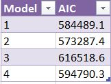

#### Table 2:Forecasts for 24 hour

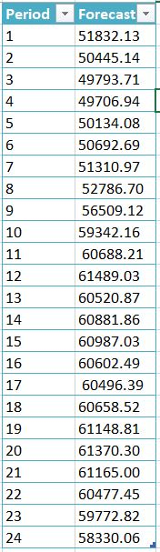

#### **b)Figures**

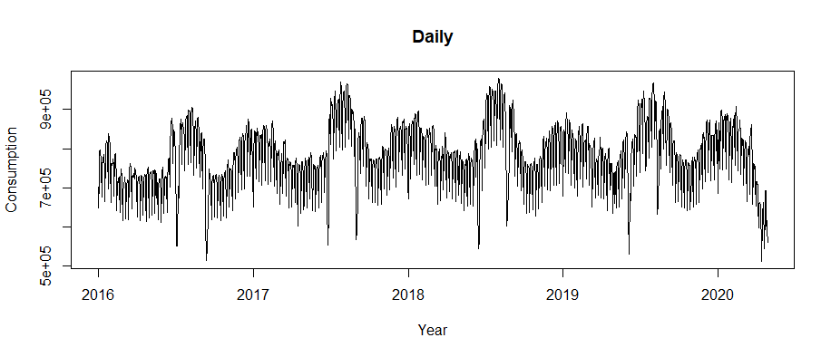

Figure 1: Plot of daily consumption

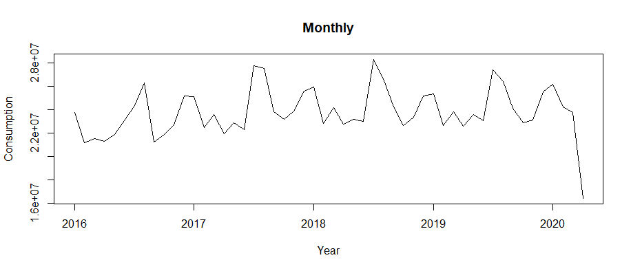

Figure 2: Plot of monthly consumption

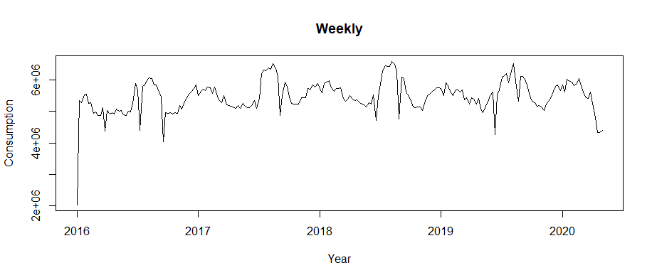

Figure 3: Plot of weekly consumption

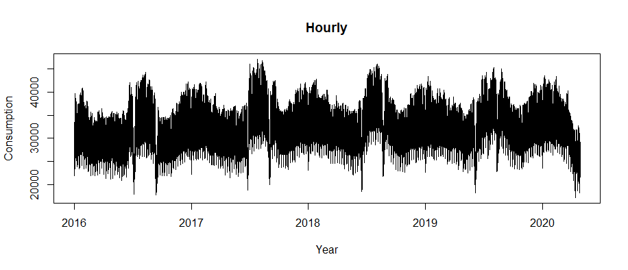

Figure 4: Plot of hourly consumption

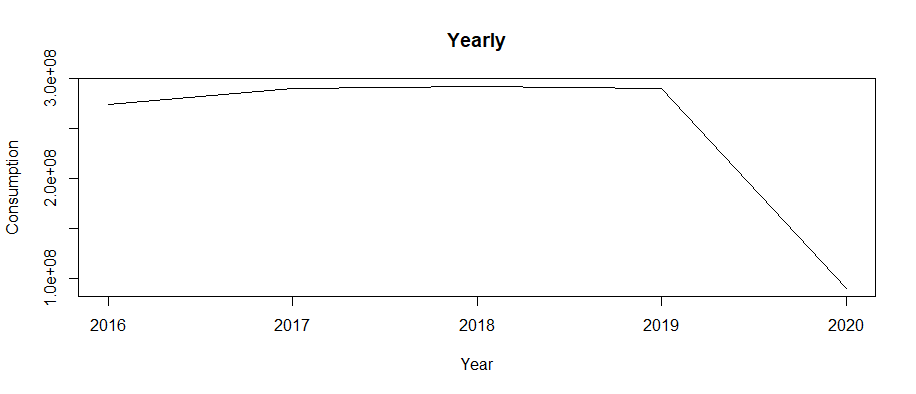

Figure 5: Plot of yearly consumption

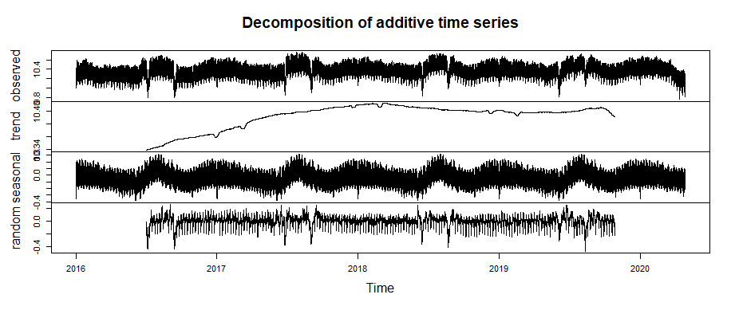

Figure 6: Plot of hourly decomposition

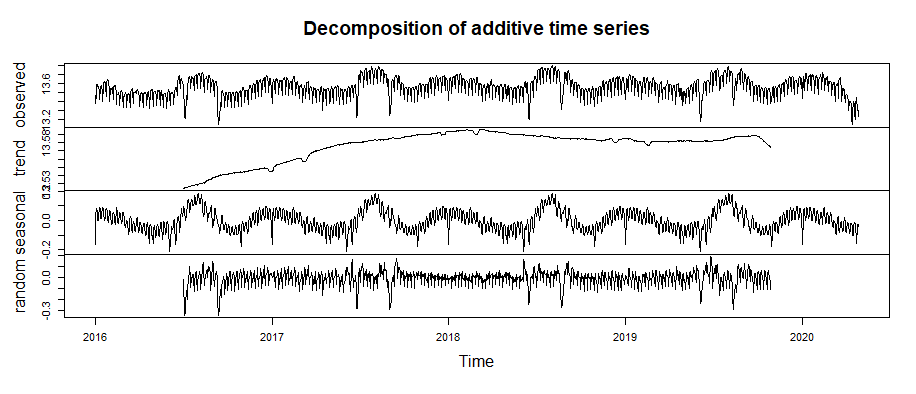

Figure 7: Plot of daily decomposition

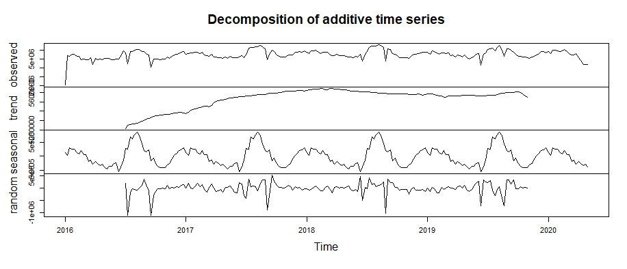

Figure 8: Plot of weekly decomposition

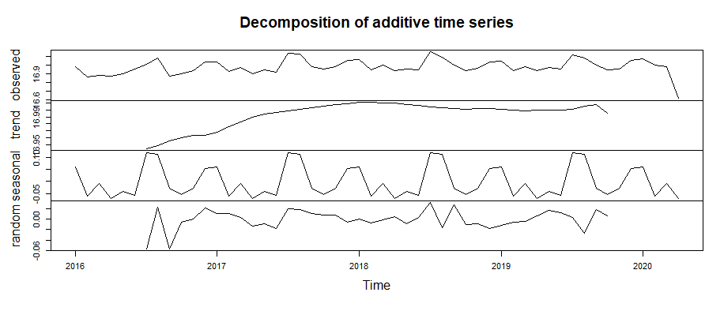

Figure 9: Plot of monthly decomposition

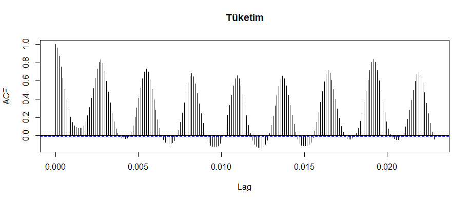

Figure 10: Acf Plot of hourly consumption

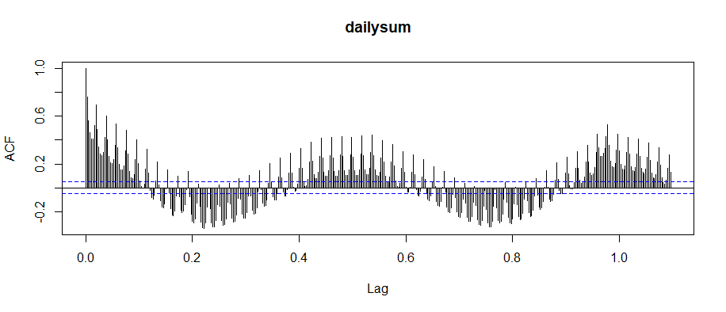

Figure 11: Acf Plot of daily consumption

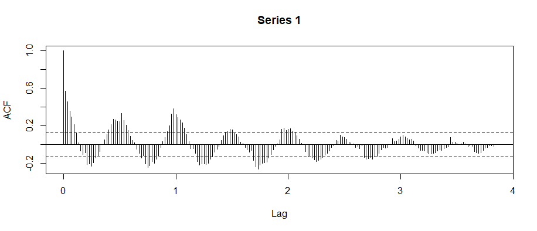

Figure 12: Acf Plot of weekly consumption

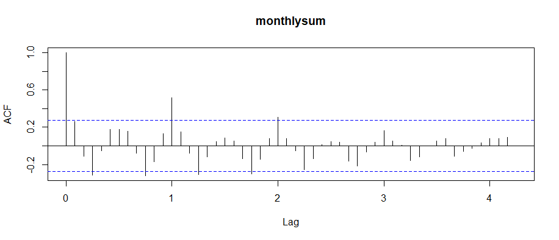

Figure 13: Acf Plot of monthly consumption

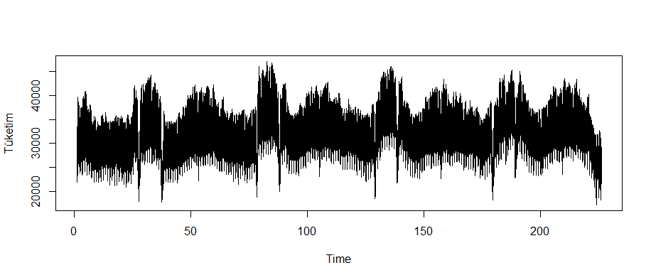

Figure 14: Plot of frequency equal to 168

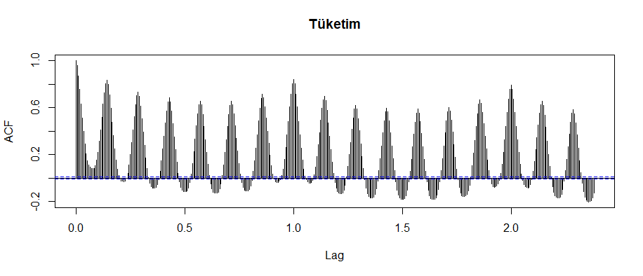

Figure 15:Acf plot of frequency equal to 168

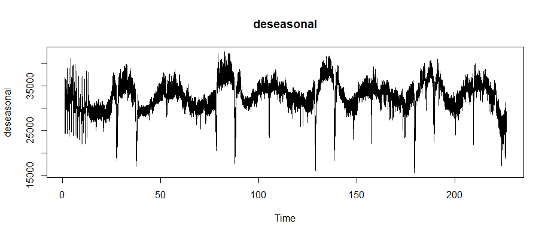

Figure 16: Plot of deseasonal series

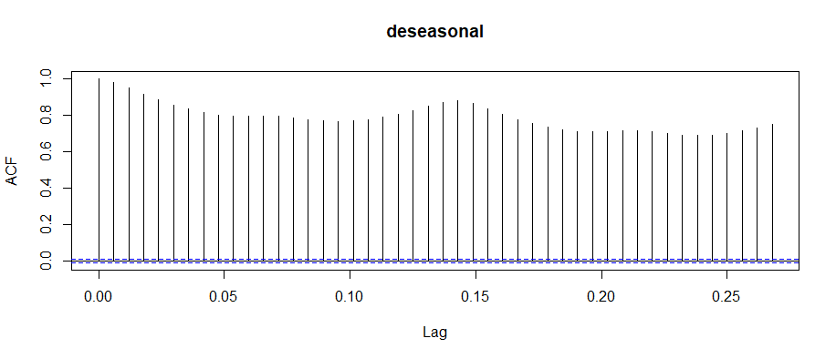

Figure 17: Acf plot of deseasonal series

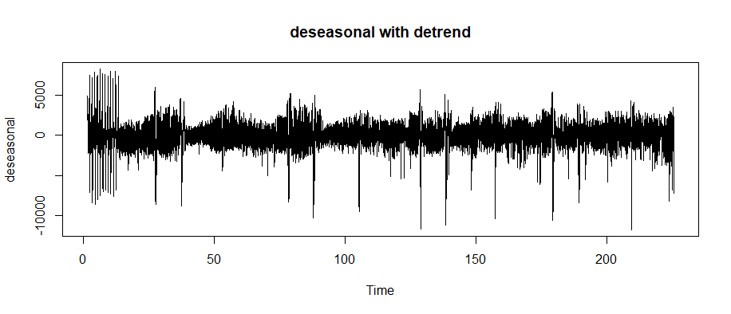

Figure 18: Plot of both deseasonal and detrend series

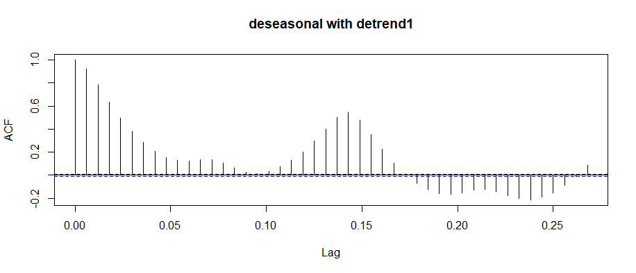

Figure 19: Acf Plot of both deseasonal and detrend series

### **5)Appendix**

#### **a)Appendix 1:R Codes for Plotting Figures**

##### Code for Figure 1

ts.plot(ts_daily,xlab = “Year”, ylab = “Consumption”, main = “Daily”)

##### Code for Figure 2

ts.plot(ts_monthly,xlab = “Year”, ylab = “Consumption”, main = “Monthly”)

##### Code for Figure 3

ts.plot(ts_weekly,xlab = “Year”, ylab = “Consumption”, main = “Weekly”)

##### Code for Figure 4

ts.plot(ts_hourly,xlab = “Year”, ylab = “Consumption”, main = “Hourly”)

##### Code for Figure 5

ts.plot(ts_yearly,xlab = “Year”, ylab = “Consumption”, main =“Yearly” )

##### Code for Figure 6

plot(dhourly)

##### Code for Figure 7

plot(ddaily)

##### Code for Figure 8

plot(dweekly)

##### Code for Figure 9

plot(dmonthly)

##### Code for Figure 10

acf(ts_hourly,lag.max=200)

##### Code for Figure 11

acf(ts_daily,lag.max=400)

##### Code for Figure 12

acf(ts_weekly,lag.max=200)

##### Code for Figure 13

acf(ts_monthly,lag.max=200)

##### Code for Figure 14

a<-ts(ts_hourly,frequency = 168) plot(a)

##### Code for Figure 15

a<-ts(ts_hourly,frequency = 168) acf(a,lag.max = 400)

##### Code for Figure 16

deseasonal<-a-dechour$seasonal  
ts.plot(deseasonal,main=‘deseasonal’)

##### Code for Figure 17

deseasonal<-a-dechour$seasonal acf(deseasonal,main=‘deseasonal’)

##### Code for Figure 18

detrend<-deseasonal-dechour$trend plot(detrend,main=‘deseasonal with detrend’)

##### Code for Figure 19

detrend<-deseasonal-dechour$trend acf(detrend, na.action=na.pass,main=‘deseasonal with detrend’)

## **6.CODE**

[Here is the github link of the code.](https://github.com/BU-IE-360/ilgazgulsen/blob/master/files/hw2.R)

install.packages(“readr”) install.packages(“forecast”) install.packages(“xlsx”) install.package(“zoo”) install.packages(“xts”) install.packages(“data.table”) install.packages(“normwhn.test”) install.packages(“na.tools”) install.packages(“stats”) library(zoo) library(readr) library(forecast) library(readxl) library(xts) library(data.table) library(normwhn.test) library(na.tools) library(stats)

datason<-data.table(read_excel(“C:/Users/LENOVO/Desktop/son.xlsx”,n_max=37850)) #Data read from Excell file datason$Tarih<-as.character(datason$Tarih) #İn order to easy to work it convert to ‘Tarih’ to character datason[,c(“year”,“month”,“day”):=tstrsplit(Tarih,“-”)] #Add 3 more column which shows year,month and day information seperately str(datason) is.ts(datason) acf(datason) datason$day=as.integer(datason$day) #Convert day,month,year to integer datason$month=as.integer(datason$month) datason$year=as.integer(datason$year)

cons_data <- datason[1:37848,3] #Select the consumption part to easier work

is.ts(cons_data) #check whether consumption is time series or not acf(cons_data) #brief look at the consumption datason[,“weekday” := format(as.Date(datason$Tarih,format = “%Y-%d-%m”),format = “%A”)] #add also the weekday column

daily<-datason[,list(dailysum=sum(Tüketim)), by = list(year,month,day)] #Aggregate hourly data to daily,monthly and yearly monthly<-datason[,list(monthlysum=sum(Tüketim)), by = list(year,month)] weekday<-datason[,list(weekdaysum=sum(Tüketim)),by=list(year,month,weekday)] yearly<-datason[,list(yearlysum=sum(Tüketim)), by = list(year)] d <-daily[,4] #select only the consumption column acf(d) plot(d) acf(monthly) acf(weekly) m<-monthly[,3] #select only the consumption column y<-yearly[,2] #select only the consumption column datason <- as.xts(datason$Tüketim,order.by=as.Date(datason$Tarih)) weekly2 <- apply.weekly(datason,sum) #aggregate hourly data to weekly data acf(daily) acf(monthly) acf(yearly) acf(weekly2)

weekday<-na.rm(weekday)

#creating time series objects  
ts_hourly<-ts(cons_data,freq=8760,start=c(2016,1,1)) # (365*24) ts_daily<-ts(d,freq=365,start=c(2016,1,1)) ts_monthly<-ts(m,freq=12,start=c(2016,1)) ts_yearly<-ts(y,freq=1,c(2016,1)) ts_weekly<-ts(weekly2,freq=52,start=c(2016,1))

acf(ts_hourly,lag.max=200) #acf of time series objects acf(ts_daily,lag.max=400) acf(ts_monthly,lag.max=200) acf(ts_weekly,lag.max=200)

ts.plot(ts_daily,xlab = “Year”, ylab = “Consumption”, main = “Daily”) #plots of time series objects ts.plot(ts_monthly,xlab = “Year”, ylab = “Consumption”, main = “Monthly”) ts.plot(ts_weekly,xlab = “Year”, ylab = “Consumption”, main = “Weekly”) ts.plot(ts_hourly,xlab = “Year”, ylab = “Consumption”, main = “Hourly”) ts.plot(ts_yearly,xlab = “Year”, ylab = “Consumption”, main =“Yearly” )

lh<-log(ts_hourly) #stabilize variance by log transformation ld<-log(ts_daily) lm<-log(ts_monthly) lw<-log(ts_weekly)

ts.plot(ts_daily) ts.plot(ld)

dhourly <-decompose(lh,type=“additive”) #decompose of time series objects in additive way ddaily <-decompose(ld,type=“additive”) dmonthly <-decompose(lm,type=“additive”) dweekly <-decompose(ts_weekly,type=“additive” )

plot(dhourly) plot(ddaily) plot(dmonthly) plot(dweekly)

seasonplot(ts_hourly) seasonplot(ts_daily)

dechour<-decompose(ts(ts_hourly, frequency = 168)) #since assumption is day+hour seasonality decompose the data plot(dechour) A[3000:37847]$trend

a<-ts(ts_hourly,frequency = 168) #Set the frequency equal 168 acf(a,lag.max = 400) #acf plot(a) #plot

deseasonal<-a-dechour$seasonal #subtract the seasonal component ts.plot(deseasonal,main=‘deseasonal’) #plot without seasonal component acf(deseasonal,main=‘deseasonal’) #acf without seasona component

detrend<-deseasonal-dechour$trend #also subtract the trend acf(detrend, na.action=na.pass,main=‘deseasonal with detrend1’) #acf without both seasonal and trend component plot(detrend,main=‘deseasonal with detrend’) #plot without both seasonal and trend component

arm <- arima(detrend, order=c(1,0,0)) #autoregressive model print(arm) AIC(arm) arm2<- arima(detrend, order=c(2,0,0)) #autoregressive model2 with different p (will be selected) print(arm2) AIC(arm2)

#part4 mam <- arima(detrend, order=c(0,0,1)) # moving average model print(mam) AIC(mam) mam2 <- arima(detrend, order=c(0,0,2)) #moving average model2 with different q print(mam2) AIC(mam2)

model_fitted <- a - residuals(ar2) points(model_fitted, type = “l”, col = 2, lty = 2) #part5 model_forecast <- predict(arm2, n.ahead = 24)$pred #prediction for 24 period

model_forecast_se <- predict(arm2, n.ahead = 24)$se #error

seasonal<-dechour$seasonal #obtain seasonality sez<-seasonal [1:24]

newtrend<-dechour$trend #obtain trend newt<-newtrend[37764] #trend of last observation trend_vector<-rep(newt,times=24)

print(newt) print(sez) print(model_forecast) print(trend_vector)

end<-model_forecast+sez+trend_vector #24 period forecasts

print(end)